# upgrades_seasonality

title: Determining if there is a seasonal component in the premium upgrades  
author: Mihai Hopirtean  
date: 2021-08-10  
region: EU  
tags: memberships, premium, upgrade, upsell, seasonality  
summary: The investigation aims to find if there is a seasonal companonet in the observed variation of upgrades. This can help explain both upticks and downticks from expected/desired/set targets at the monthly level.

### Import relevant packages and data

```python
import pandas as pd
from statsmodels.tsa.seasonal import STL
from statsmodels.tsa.seasonal import seasonal_decompose
import matplotlib.pyplot as plt
import seaborn as sns
%matplotlib inline
```

```python
#fetch upgrades, volumes, all tiers

query = """

select dwh.start_time::date,
       count(distinct dbt.zrh_user_product.user_created) as upgrades
from dwh_cohort_months as dwh
         left join dbt.zrh_user_product
                   on dbt.zrh_user_product.enter_reason = 'UPGRADED'
                       and
                      dbt.zrh_user_product.subscription_valid_from between dwh.end_time - interval '35 days' and dwh.end_time
                       and is_premium
where dwh.start_time >= '2017-01-01'
  and dwh.start_time < '2021-08-01'
  and market != 'GBR'
group by 1
order by 1

"""
```

```python
uva = pd.read_csv('data/upgrades_v_all.csv', parse_dates=['start_time'])
uva.head()
```

|  | start_time | upgrades |
| --- | --- | --- |
| 0 | 2017-01-01 | 1155 |
| 1 | 2017-02-01 | 600 |
| 2 | 2017-03-01 | 952 |
| 3 | 2017-04-01 | 843 |
| 4 | 2017-05-01 | 777 |

##### Plot the observed upgrade volumes since Jan 2017

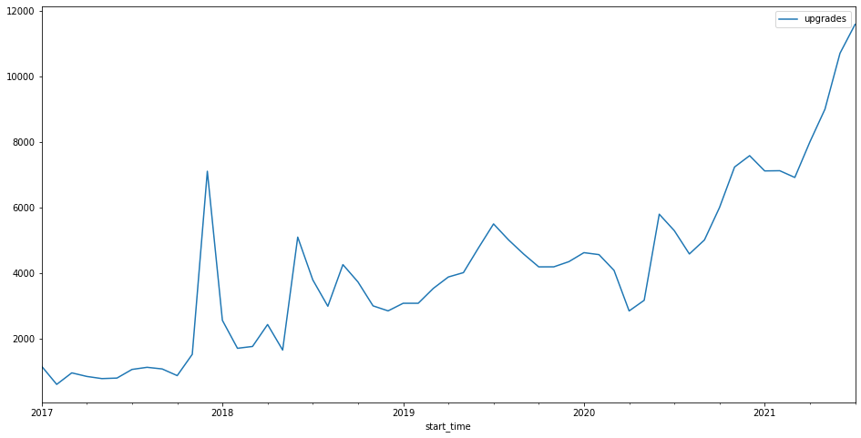

```python
uva.plot(x='start_time', y='upgrades', figsize=(16,8));
```

From the above chart it seems there may be several spikes during a calendar year, so there might be a seasonality under one year. Intuitively, there may also be large residuals.

```python
uva.info()
```

```
<class 'pandas.core.frame.DataFrame'>
RangeIndex: 55 entries, 0 to 54
Data columns (total 2 columns):
 #   Column      Non-Null Count  Dtype
---  ------      --------------  -----
 0   start_time  55 non-null     datetime64[ns]
 1   upgrades    55 non-null     int64
dtypes: datetime64[ns](1), int64(1)
memory usage: 1008.0 bytes
```

```python
uva = uva.set_index('start_time')
```

```python
uva = uva.asfreq('MS')
```

```python
uva.index
```

```
DatetimeIndex(['2017-01-01', '2017-02-01', '2017-03-01', '2017-04-01',
               '2017-05-01', '2017-06-01', '2017-07-01', '2017-08-01',
               '2017-09-01', '2017-10-01', '2017-11-01', '2017-12-01',
               '2018-01-01', '2018-02-01', '2018-03-01', '2018-04-01',
               '2018-05-01', '2018-06-01', '2018-07-01', '2018-08-01',
               '2018-09-01', '2018-10-01', '2018-11-01', '2018-12-01',
               '2019-01-01', '2019-02-01', '2019-03-01', '2019-04-01',
               '2019-05-01', '2019-06-01', '2019-07-01', '2019-08-01',
               '2019-09-01', '2019-10-01', '2019-11-01', '2019-12-01',
               '2020-01-01', '2020-02-01', '2020-03-01', '2020-04-01',
               '2020-05-01', '2020-06-01', '2020-07-01', '2020-08-01',
               '2020-09-01', '2020-10-01', '2020-11-01', '2020-12-01',
               '2021-01-01', '2021-02-01', '2021-03-01', '2021-04-01',
               '2021-05-01', '2021-06-01', '2021-07-01'],
              dtype='datetime64[ns]', name='start_time', freq='MS')
```

### Try to identify the trend and seasonal component in the time series

#### Use the "naive decomposition" implemented in seasonal_decompose

```python
result = seasonal_decompose(uva, model='additive')
```

```python
plt.rc('figure',figsize=(16,12))
plt.rc('font',size=13)
```

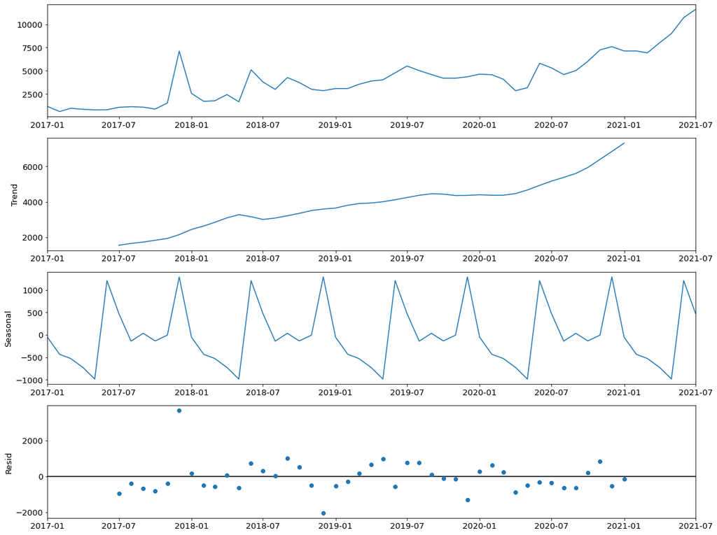

```python
result.plot();
```

This method already identifies a seasonal pattern and it may just as well correspond to the upticks observed before the end of the calendar year and around midyear.

However, this method is not robust to outliers and in N26's case, these may occur due to various product and/or marketing initiatives. Therefore, one can also use STL (Seasonal Trend decomposition using Locally estimated scatterplot smoothing), which carries further advantages over simple decomposition.

#### Use STL decomposition

Use both a robust and non-robust decomposition for comparison.

```python
def add_stl_plot(fig, res, legend):
    """Add 3 plots from a second STL fit"""
    axs = fig.get_axes()
    comps = ['trend', 'seasonal', 'resid']
    for ax, comp in zip(axs[1:], comps):
        series = getattr(res, comp)
        if comp == 'resid':
            ax.plot(series, marker='o', linestyle='none')
        else:
            ax.plot(series)
            if comp == 'trend':
                ax.legend(legend, frameon=False)
```

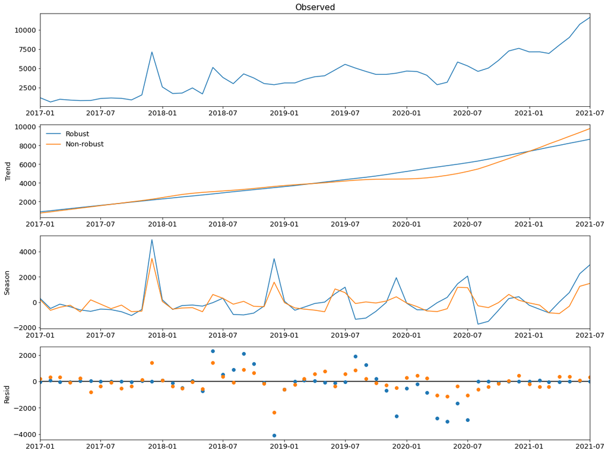

```python
stl = STL(uva, period = 12, robust=True)
res_robust = stl.fit()
fig = res_robust.plot()
res_non_robust = STL(uva, period = 12, robust=False).fit()
add_stl_plot(fig, res_non_robust, ['Robust','Non-robust'])
```

The above robust (blue series) decomposition may be interesting to interpret and make sense of, however:

- the trend component is linear
- within a 12 month period we observe two peaks in the seasonal component: one before the end of the year and another one right after the middle of a calendar year
- the above mentioned two peaks have a balancing evolution: while the end of the year peak is decreasing over time, the midyear peak is increasing over time
- the residuals have rather high values especially for dates around the seasonal peaks, however for data closer to the present their values are smaller and smaller.

Here the advantage of STL can be observed, in that it allows the seasonal component to vary over time and produces a stable, linear trend unlike seasonal_decompose which forces a stable seasonal component.

This is particularly valuable in the context of shifting consumer patterns.

Particularly, **as product tiers have changed over time (i.e. benefits have been concentrated in the *upper* tiers, especially travel-related benefits), so might have consumers' behaviors adapted to these changes** and to the immediate benefits and value brought by these tiers to them.

It will be worth revisiting this analysis in 6 months' time for re-evaluation and see if the observations made will hold.

#### Use the share of standard MAUs that upgrade instead of absolute upgrade volumes

```python
uva_r = pd.read_csv('data/upgrade_rate.csv', parse_dates=['start_time'])
uva_r.head()
```

|  | start_time | rate |
| --- | --- | --- |
| 0 | 2017-01-01 | 0.009974 |
| 1 | 2017-02-01 | 0.005089 |
| 2 | 2017-03-01 | 0.007971 |
| 3 | 2017-04-01 | 0.006743 |
| 4 | 2017-05-01 | 0.005895 |

```python
uva_r = uva_r.set_index('start_time')
uva_r = uva_r.asfreq('MS')
uva_r.index
```

```
DatetimeIndex(['2017-01-01', '2017-02-01', '2017-03-01', '2017-04-01',
               '2017-05-01', '2017-06-01', '2017-07-01', '2017-08-01',
               '2017-09-01', '2017-10-01', '2017-11-01', '2017-12-01',
               '2018-01-01', '2018-02-01', '2018-03-01', '2018-04-01',
               '2018-05-01', '2018-06-01', '2018-07-01', '2018-08-01',
               '2018-09-01', '2018-10-01', '2018-11-01', '2018-12-01',
               '2019-01-01', '2019-02-01', '2019-03-01', '2019-04-01',
               '2019-05-01', '2019-06-01', '2019-07-01', '2019-08-01',
               '2019-09-01', '2019-10-01', '2019-11-01', '2019-12-01',
               '2020-01-01', '2020-02-01', '2020-03-01', '2020-04-01',
               '2020-05-01', '2020-06-01', '2020-07-01', '2020-08-01',
               '2020-09-01', '2020-10-01', '2020-11-01', '2020-12-01',
               '2021-01-01', '2021-02-01', '2021-03-01', '2021-04-01',
               '2021-05-01', '2021-06-01', '2021-07-01', '2021-08-01'],
              dtype='datetime64[ns]', name='start_time', freq='MS')
```

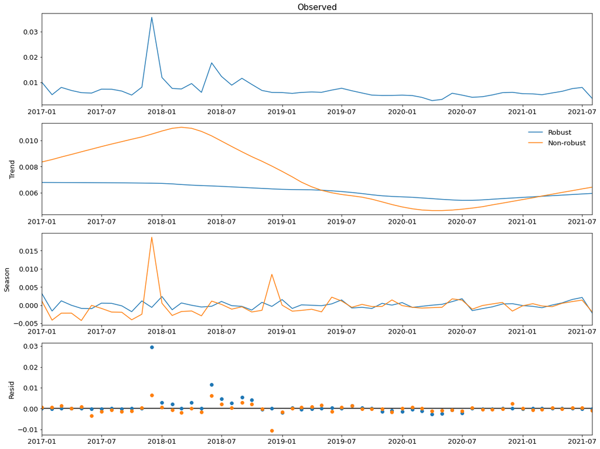

```python
stl_r = STL(uva_r, period = 12, robust=True)
res_robust_r = stl_r.fit()
fig_r = res_robust_r.plot()
res_non_robust_r = STL(uva_r, period = 12, robust=False).fit()
add_stl_plot(fig_r, res_non_robust_r, ['Robust','Non-robust'])
```

In this situation, we can see that the non-robust (sensitive to outliers) trend line has a higher variation.  
The robust method, however, shows a slightly decreasing trend with virtually no distinguishable seasonality and higher residuals.

### Conclusion

There seems to be a seasonal component in the upgrade behavior when analyzing absolute volumes: two peaks (one around mid year increasing in amplitude over time, and another one before the end of the year decreasing in amplitude over time) can explain some of the ups and downs observed in our data.  
There doesn't seem to be any distinguishable seasonality when analyzing the share of standard MAUs that upgrade.

Combining the two above might lead to the conclusion that the upgrade rate has no distinguishable seasonality, but the absolute volumes follow new user acquisition/MAU activation trends.

###### Further reading

- [STL article](http://www.wessa.net/download/stl.pdf)
- [Time series decomposition](https://otexts.com/fpp2/decomposition.html)